# Causal Inference Methods for Policy Evaluation

02-Subclassification and Matching

Jacopo Mazza

Utrecht School of Economics

2026

# Subclassification

## Should we ban tobacco advertisement?

[figure not shown]

## Should we ban tobacco advertisement?

[figure not shown]

- Many countries have banned tobacco advertisement
- Reason?
  - Tobacco advertisement increases smoking
  - Smoking **causes** cancer

## Does smoking cause cancer?

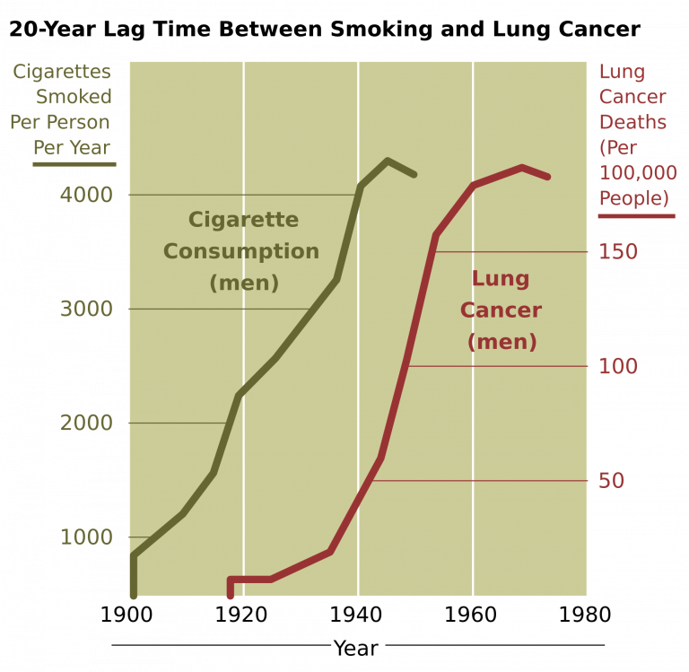

US data on smoking and lung cancer

## Does smoking cause cancer?

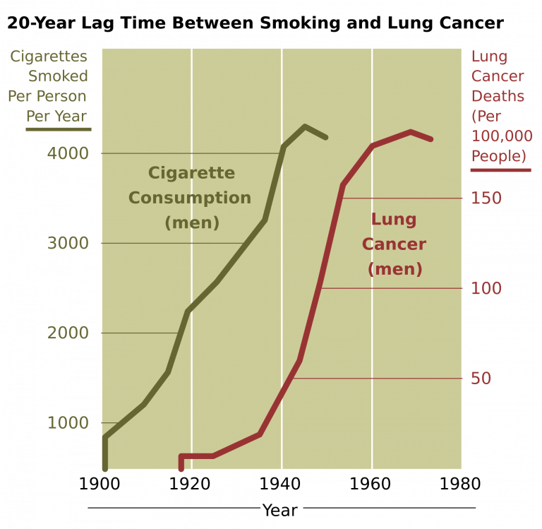

- There is a strong correlation between smoking and lung cancer
- Does this mean that smoking causes cancer?
- Are smokers and non-smokers the same type of people?
  - Do they have the same lifestyle?
  - Do they have the same genetic predisposition?
  - Do they have the same access to healthcare?
- Can we compare the health of smokers and non-smokers?
  - Can we say that $E[Y_i^0|D_i=1] = E[Y_i^0|D_i=0]$?

## Death Rates by Smoking Status

Death rates per 1,000 people ([Cochran 1968](https://www.jstor.org/stable/2528036?origin=crossref))

| Smoking status | Canada | UK | US |
| --- | --- | --- | --- |
| Non-smoker | 20.2 | 11.3 | 13.5 |
| Cigarettes | 20.5 | 14.1 | 13.5 |
| Cigars/pipes | 35.5 | 20.7 | 17.4 |

## Death Rates by Smoking Status

| Smoking status | Canada | UK | US |
| --- | --- | --- | --- |
| Non-smoker | 20.2 | 11.3 | 13.5 |
| Cigarettes | 20.5 | 14.1 | 13.5 |
| Cigars/pipes | 35.5 | 20.7 | 17.4 |

- Highest death rates for cigars/pipe smokers
- Lowest death rates for non-smokers
- Death rates for cigarette smokers are not very different than those of non-smokers
- If smoking tobacco **causes** higher death rates cigarettes smokers should be the most affected
- Data suggests that cigars and pipes are more dangerous than cigarettes
- But is this true?
  - is $E[Y^1|Cigarettes]=E[Y^1|Cigars/pipes]$?
  - and $E[Y^0|Cigarettes]=E[Y^0|Cigars/pipes]$?
- We know that mortality is affected by other factors (age, education, etc.)
- If $E[Y^0|Cigarettes]=E[Y^0|Cigars/pipes]$ then groups should be the same by these factors
- We call this **balance**

## Age Balance?

Ages in years

| Smoking status | Canada | UK | US |
| --- | --- | --- | --- |
| Non-smoker | 54.9 | 49.1 | 57.0 |
| Cigarettes | 50.5 | 49.8 | 53.2 |
| Cigars/pipes | 65.9 | 55.7 | 59.7 |

- The two groups are not balanced by age
- Older people are more likely to smoke cigars/pipes
- Older people are more likely to die
- Maybe higher death rates for cigars/pipes are due to age
- Age is a **confounder**: it affects both smoking and death

## Subclassification for Balance

Subclassification, example

| Age | Death rate cigarette smokers | Nr. cigarette smokers | Nr. pipe/cigar smokers |
| --- | --- | --- | --- |
| 20-40 | 20 | 65 | 10 |
| 41-70 | 40 | 25 | 25 |
| $\geq$ 70 | 60 | 10 | 65 |
| Total |  | 100 | 100 |

- Divide age into *strata*
- Weight the mortality rate of the treatment group (cigarettes) by the proportion of the control group in each stratum
- In this example:
  - What is the weighted mortality rate for cigarettes?
    $$\frac{65}{100} \times 20 + \frac{25}{100} \times 40 + \frac{10}{100} \times 60 = 29$$
  - What would be the mortality rate for cigarettes smoker if they had the same age as pipe/cigars smokers?
    $$\frac{10}{100} \times 20 + \frac{25}{100} \times 40 + \frac{65}{100} \times 60 = 51$$

## Adjusted Mortality Rates

Adjusted mortality rates per 1,000 people

| Smoking status | Canada | UK | US |
| --- | --- | --- | --- |
| Non-smoker | 20.2 | 11.3 | 13.5 |
| Cigarettes | 29.5 | 14.8 | 21.2 |
| Cigars/pipes | 19.8 | 11.0 | 13.7 |

- Adjusted, by age, mortality rates are **higher** for cigarette smokers
- Which variables should we adjust for?
  - Variables that affect both treatment and outcome
  - Variables that are **confounders**

# The Titanic Example

- The Titanic was a British passenger liner that sank in the North Atlantic Ocean in 1912
- The ship carried 2,224 passengers and crew
- About 700 survived
- Wealthier passengers were more likely to survive
- Was it because they were seated in the upper decks?
- Or was it because women and children were seated in the upper decks?

## Titanic Data

```r
library(tidyverse)
library(haven)

# Define a function to read data from a URL
read_data <- function(df)
{
  # Combine the base URL with the file name
  full_path <- paste("https://github.com/scunning1975/mixtape/raw/master/",
                     df, sep = "")
  # Read the .dta file from the URL
  df <- read_dta(full_path)
  # Return the data frame
  return(df)
}

# Read the 'titanic.dta' data and create a new variable 'd'
titanic <- read_data("titanic.dta") %>%
  mutate(d = case_when(class == 1 ~ 1, TRUE ~ 0)) # 'd' is 1 if 'class' is 1, 0 otherwise

# Calculate the mean of 'survived' for observations where 'd' is 1
ey1 <- titanic %>%
  filter(d == 1) %>%
  pull(survived) %>%
  mean()

# Calculate the mean of 'survived' for observations where 'd' is 0
ey0 <- titanic %>%
  filter(d == 0) %>%
  pull(survived) %>%
  mean()

# Calculate the difference in means
sdo <- ey1 - ey0

# Create a data frame
results <- data.frame(
  ey1 = ey1,
  ey0 = ey0,
  sdo = sdo
)

# Print the data frame
print(results)
```

```
        ey1       ey0       sdo
1 0.6246154 0.2707889 0.3538265
```

- Difference in means: 35%

## Titanic with Strata

- 35% is the simple, unadjusted difference in means
- What if we adjust for age and sex?
- We can use subclassification in 4 steps:
  - Define 4 strata: young men, young women, old men, old women
  - Calculate the difference in survival rates in each stratum
  - Calculate the stratum-specific weights
  - Calculate the weighted average survival rate

## Titanic with Strata

```r
library(stargazer)
library(magrittr) # for %$% pipes
library(tidyverse)
library(haven)

# Read the 'titanic.dta' data and create new variables 'd' and 's'
titanic <- read_data("titanic.dta") %>%
  mutate(d = case_when(class == 1 ~ 1, TRUE ~ 0)) %>% # 'd' is 1 if 'class' is 1, 0 otherwise
  mutate(s = case_when(sex == 0 & age == 1 ~ 1,        # 's' is a categorical variable based on 'sex' and 'age'
                       sex == 0 & age == 0 ~ 2,
                       sex == 1 & age == 1 ~ 3,
                       sex == 1 & age == 0 ~ 4,
                       TRUE ~ 0))

# Calculate the mean of 'survived' for different groups
ey11 <- titanic %>% filter(s == 1 & d == 1) %$% mean(survived)
ey10 <- titanic %>% filter(s == 1 & d == 0) %$% mean(survived)
ey21 <- titanic %>% filter(s == 2 & d == 1) %$% mean(survived)
ey20 <- titanic %>% filter(s == 2 & d == 0) %$% mean(survived)
ey31 <- titanic %>% filter(s == 3 & d == 1) %$% mean(survived)
ey30 <- titanic %>% filter(s == 3 & d == 0) %$% mean(survived)
ey41 <- titanic %>% filter(s == 4 & d == 1) %$% mean(survived)
ey40 <- titanic %>% filter(s == 4 & d == 0) %$% mean(survived)

# Calculate the differences in means
diff1 = ey11 - ey10
diff2 = ey21 - ey20
diff3 = ey31 - ey30
diff4 = ey41 - ey40

# Calculate the number of observations where 'd' is 0
obs = nrow(titanic %>% filter(d == 0))

# Calculate weights for each group
wt1 <- titanic %>% filter(s == 1 & d == 0) %>% nrow() / obs
wt2 <- titanic %>% filter(s == 2 & d == 0) %>% nrow() / obs
wt3 <- titanic %>% filter(s == 3 & d == 0) %>% nrow() / obs
wt4 <- titanic %>% filter(s == 4 & d == 0) %>% nrow() / obs

# Calculate the weighted average treatment effect
wate = diff1*wt1 + diff2*wt2 + diff3*wt3 + diff4*wt4

# Put wate and sdo into a data frame
results <- data.frame(wate = wate, sdo = sdo)

# Use stargazer to create a table
stargazer(results, type = "text")
```

```
======================================
Statistic N Mean  St. Dev.  Min   Max
--------------------------------------
wate      1 0.189          0.189 0.189
sdo       1 0.354          0.354 0.354
--------------------------------------
```

## Curse of Dimensionality

- Subclassification works as long as we have enough treated and non-treated observations in each stratum
- What if we have a lot of strata?
  - Example: precise age instead of age groups.
  - There are no 14-year-old boys in first class
  - We cannot calculate the difference in means for this group
  - We cannot calculate the ATE using subclassification
- This is the **curse of dimensionality**
- We need to use other methods

# Matching

## Exact Matching

- When there are many covariates, subclassification is not feasible
- We could impute the missing potential outcomes:
  - For each treated observation, find the non-treated observation with the closest covariates
  - Use the non-treated observation to impute the missing potential outcomes
  - Repeat for all treated observations
- This is called **exact matching**

## Exact Matching for Work Training Programs

Job Training Program and Earnings

| Trainees |  |  | Non-Trainees |  |  |
| --- | --- | --- | --- | --- | --- |
| Unit | Age | Earnings | Unit | Age | Earnings |
| 1 | 18 | 9500 | 1 | 20 | 8500 |
| 2 | 29 | 12250 | 2 | 27 | 10075 |
| 3 | 24 | 11000 | 3 | 21 | 8725 |
| 4 | 27 | 11750 | 4 | 39 | 12775 |
| 5 | 33 | 13250 | 5 | 38 | 12550 |
| 6 | 22 | 10500 | 6 | 29 | 10525 |
| 7 | 19 | 9750 | 7 | 39 | 12775 |
| 8 | 20 | 10000 | 8 | 33 | 11425 |
| 9 | 21 | 10250 | 9 | 24 | 9400 |
| 10 | 30 | 12500 | 10 | 30 | 10750 |
|  |  |  | 11 | 33 | 11425 |
|  |  |  | 12 | 36 | 12100 |
|  |  |  | 13 | 22 | 8950 |
|  |  |  | 14 | 18 | 8050 |
|  |  |  | 15 | 43 | 13675 |
|  |  |  | 16 | 39 | 12775 |
|  |  |  | 17 | 19 | 8275 |
|  |  |  | 18 | 30 | 9000 |
|  |  |  | 19 | 51 | 15475 |
|  |  |  | 20 | 48 | 14800 |
| Mean | 24.3 | $11,075 | Mean | 31.95 | $11,101.25 |

## Exact Matching for Work Training Programs

| Trainees |  |  | Non-Trainees |  |  |
| --- | --- | --- | --- | --- | --- |
| Unit | Age | Earnings | Unit | Age | Earnings |
| 1 | 18 | 9500 | 1 | 20 | 8500 |
| 2 | 29 | 12250 | 2 | 27 | 10075 |
| 3 | 24 | 11000 | 3 | 21 | 8725 |
| 4 | 27 | 11750 | 4 | 39 | 12775 |
| 5 | 33 | 13250 | 5 | 38 | 12550 |
| 6 | 22 | 10500 | 6 | 29 | 10525 |
| 7 | 19 | 9750 | 7 | 39 | 12775 |
| 8 | 20 | 10000 | 8 | 33 | 11425 |
| 9 | 21 | 10250 | 9 | 24 | 9400 |
| 10 | 30 | 12500 | 10 | 30 | 10750 |
|  |  |  | 11 | 33 | 11425 |
|  |  |  | 12 | 36 | 12100 |
|  |  |  | 13 | 22 | 8950 |
|  |  |  | 14 | 18 | 8050 |
|  |  |  | 15 | 43 | 13675 |
|  |  |  | 16 | 39 | 12775 |
|  |  |  | 17 | 19 | 8275 |
|  |  |  | 18 | 30 | 9000 |
|  |  |  | 19 | 51 | 15475 |
|  |  |  | 20 | 48 | 14800 |
| Mean | 24.3 | $11,075 | Mean | 31.95 | $11,101.25 |

- What is the effect of the training program?
- We have a sample of trainees and non-trainees
- Age differs between the two groups
- Age is a confounder: it affects earnings
- We can use exact matching to adjust for age

## The Non Exchangeability of Age

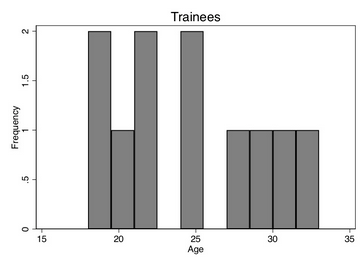

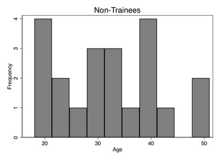

```r
library(tidyverse)
library(haven)

read_data <- function(df)
{
  full_path <- paste("https://github.com/scunning1975/mixtape/raw/master/",
                     df, sep = "")
  df <- read_dta(full_path)
  return(df)
}

training_example <- read_data("training_example.dta") %>%
  slice(1:20)

ggplot(training_example, aes(x=age_treat)) +
  stat_bin(bins = 10, na.rm = TRUE)

ggplot(training_example, aes(x=age_control)) +
  geom_histogram(bins = 10, na.rm = TRUE)
```

## Exact Matching at Work

| Trainees |  |  | Non-Trainees |  |  | Matched Sample |  |  |
| --- | --- | --- | --- | --- | --- | --- | --- | --- |
| Unit | Age | Earnings | Unit | Age | Earnings | Unit | Age | Earnings |
| 1 | 18 | 9500 | 1 | 20 | 8500 | 14 | 18 | 8050 |
| 2 | 29 | 12250 | 2 | 27 | 10075 | 6 | 29 | 10525 |
| 3 | 24 | 11000 | 3 | 21 | 8725 | 9 | 24 | 9400 |
| 4 | 27 | 11750 | 4 | 39 | 12775 | 2 | 27 | 10075 |
| 5 | 33 | 13250 | 5 | 38 | 12550 | 11 | 33 | 11425 |
| 6 | 22 | 10500 | 6 | 29 | 10525 | 13 | 22 | 8950 |
| 7 | 19 | 9750 | 7 | 39 | 12775 | 17 | 19 | 8275 |
| 8 | 20 | 10000 | 8 | 33 | 11425 | 1 | 20 | 8500 |
| 9 | 21 | 10250 | 9 | 24 | 9400 | 3 | 21 | 8725 |
| 10 | 30 | 12500 | 10 | 30 | 10750 | 10,18 | 30 | 9875 |
|  |  |  | 11 | 33 | 11425 |  |  |  |
|  |  |  | 12 | 36 | 12100 |  |  |  |
|  |  |  | 13 | 22 | 8950 |  |  |  |
|  |  |  | 14 | 18 | 8050 |  |  |  |
|  |  |  | 15 | 43 | 13675 |  |  |  |
|  |  |  | 16 | 39 | 12775 |  |  |  |
|  |  |  | 17 | 19 | 8275 |  |  |  |
|  |  |  | 18 | 30 | 9000 |  |  |  |
|  |  |  | 19 | 51 | 15475 |  |  |  |
|  |  |  | 20 | 48 | 14800 |  |  |  |
| Mean | 24.3 | $11,075 | Mean | 31.95 | $11,101.25 | Mean | 24.3 | $9,380 |

- We can match each trainee with a non-trainee with the same age
- If there are more non-trainees of the same age of a trainee, we can average the earnings of the non-trainees
- Mean age of the matched sample is 24.3 –> same as trainees
- The matched sample and the trainee sample are balanced by age
- We can compare the earnings of the two groups:
  - The training program increases earnings by 1,695 dollars

## Covariate Distribution After Matching

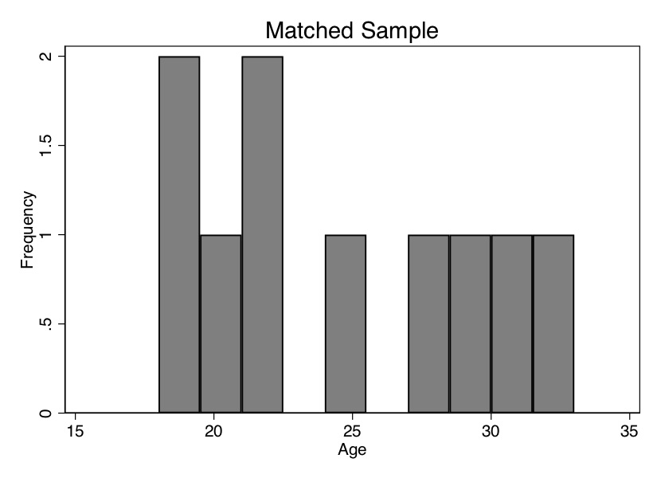

## Approximate Matching

What if we cannot find a non-trainee with the same age of a trainee?

1. Nearest neighbor matching
   - Find the non-trainee with the closest age
   - If there are more non-trainees with the same age, average their earnings
2. Propensity score matching
   - Estimate the probability of being a trainee (propensity score)
   - Match trainees and non-trainees with similar propensity scores
   - If there are more non-trainees with the same propensity score, average their earnings

## Nearest Neighbor Covariate Matching

- If number of covariates grows, it becomes more difficult to find a non-trainee with the same covariates
- We can find the non-trainee with the closest covariates
- What does close mean in this context?
  - With one covariate, trivial to define
  - With many covariates, we need to define a distance metric
  - Two common distance metrics:
    1. Euclidean distance
    2. Mahalanobis distance

## Propensity Score Methods

- The propensity score is the probability of being a trainee given the covariates
- It is usually estimated with a logit or a probit
- The probabilities are used to match treated and non-treated units
- Example:
  - 2 units A and B have the same propensity score (probability of treatment) but for some reason A is treated and B is not
  - We match A with B and use B’s outcome to impute A’s potential outcomes
- If my model captures all the relevant covariates then:  
  $E[Y^0|D=1, P(x)]=E[Y^0|D=0,P(x)]$

## Propensity Score Matching - Assumptions

Propensity score matching requires two assumptions:

1. **Common support**: there is overlap in the propensity score distribution of the treated and non-treated units
2. **Unconfoundedness**: conditional on the propensity score, treatment assignment is independent of potential outcomes

**Important**

Propensity score matching will give you unbiased estimates of the ATE if your model captures all relevant factors for selection.

## Propensity Score in Action

- [Lalonde](https://www.jstor.org/stable/1806062)<sup>1</sup> wanted to study how effective the National Supported Work Demonstration (NSW)
- NSW was a work training program for disadvantaged workers to move back in the labor market
- Workers were randomly assigned to the program
- Since we have the `real` treatment effect, we can compare the results of econometric methods with the true effect
[^1]: Lalonde, R. J. (1986). Evaluating the econometric evaluations of training programs with experimental data. *American Economic Review*, 76(4): 604-620.

## The NSW Earning Comparison

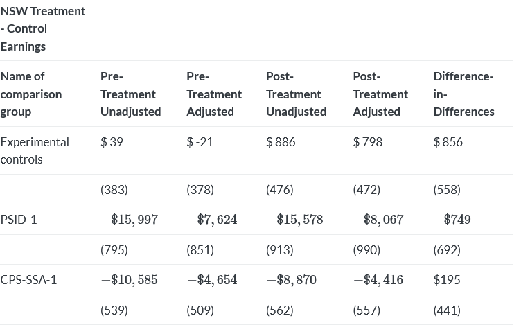

## The Balance of Covariates in the NSW Data

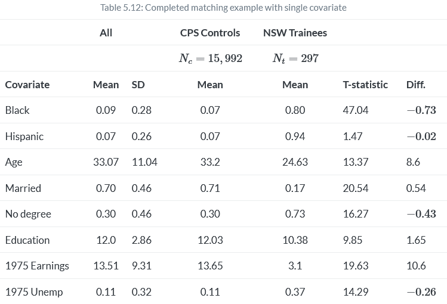

## Propensity Score Matching for the NSW Data

- [Dehejia and Wahba (1999)](https://www.jstor.org/stable/2669919)<sup>1</sup> re-analyzed the NSW data using propensity score matching
- Their main interest was to compare the performance of PSM with standard econometric methods
[^2]: Dehejia, R. H., & Wahba, S. (1999). Causal effects in nonexperimental studies: Reevaluating the evaluation of training programs. *Journal of the American Statistical Association*, 94(448): 1053-1062.

## Estimated Training Effects using Propensity Scores

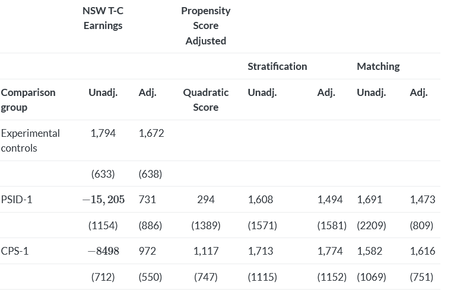

## The Balance of Covariates in the Propensity Score Matching

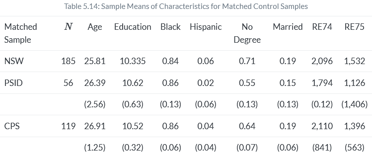

## The NSW Real Treatment Effect

```r
library(tidyverse)
library(haven)

# Define a function to read data from a .dta file hosted on GitHub
read_data <- function(df)
{
  # Construct the full URL to the file
  full_path <- paste("https://github.com/scunning1975/mixtape/raw/master/", df, sep = "")

  # Read the .dta file from the URL and return the resulting data frame
  df <- read_dta(full_path)
  return(df)
}

# Use the read_data function to read the "nsw_mixtape.dta" file
nsw_dw <- read_data("nsw_mixtape.dta")

# Calculate the mean of 're78' for rows where 'treat' equals 1
mean1 <- nsw_dw %>%
  filter(treat == 1) %>%
  pull(re78) %>%
  mean()

# Add a new column 'y1' to the data frame, with all values set to 'mean1'
nsw_dw$y1 <- mean1

# Calculate the mean of 're78' for rows where 'treat' equals 0
mean0 <- nsw_dw %>%
  filter(treat == 0) %>%
  pull(re78) %>%
  mean()

# Add a new column 'y0' to the data frame, with all values set to 'mean0'
nsw_dw$y0 <- mean0

# Calculate the Average Treatment Effect (ATE) as the difference between 'mean1' and 'mean0'
ate <- mean1 - mean0

# Create a data frame with the ATE and print it
ate_df <- data.frame(ATE = ate)
print(ate_df)
```

```
       ATE
1 1794.342
```

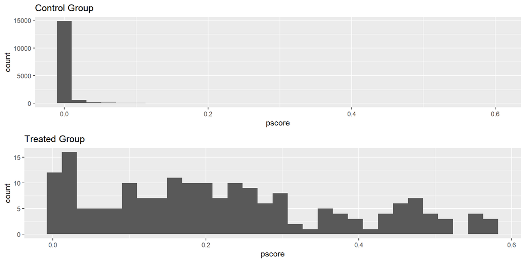

```r
# Load the necessary libraries
library(tidyverse)
library(haven)
library(gridExtra)

# Define a function to read data from a .dta file hosted on GitHub
read_data <- function(df)
{
  # Construct the full URL to the file
  full_path <- paste("https://github.com/scunning1975/mixtape/raw/master/", df, sep = "")

  # Read the .dta file from the URL and return the resulting data frame
  df <- read_dta(full_path)
  return(df)
}

# Use the read_data function to read the "cps_mixtape.dta" file
# Bind the rows of the new data frame with the existing 'nsw_dw' data frame
# Create new variables in the data frame
nsw_dw_cpscontrol <- read_data("cps_mixtape.dta") %>%
  bind_rows(nsw_dw) %>%
  mutate(agesq = age^2,
         agecube = age^3,
         educsq = educ*educ,
         u74 = case_when(re74 == 0 ~ 1, TRUE ~ 0),
         u75 = case_when(re75 == 0 ~ 1, TRUE ~ 0),
         interaction1 = educ*re74,
         re74sq = re74^2,
         re75sq = re75^2,
         interaction2 = u74*hisp)

# Estimate a logistic regression model with 'treat' as the dependent variable
logit_nsw <- glm(treat ~ age + agesq + agecube + educ + educsq +
                   marr + nodegree + black + hisp + re74 + re75 + u74 +
                   u75 + interaction1, family = binomial(link = "logit"),
                 data = nsw_dw_cpscontrol)

# Add the predicted probabilities from the logistic regression model to the data frame
nsw_dw_cpscontrol <- nsw_dw_cpscontrol %>%
  mutate(pscore = logit_nsw$fitted.values)

# Calculate the mean predicted probability for the control group
pscore_control <- nsw_dw_cpscontrol %>%
  filter(treat == 0) %>%
  pull(pscore) %>%
  mean()

# Calculate the mean predicted probability for the treated group
pscore_treated <- nsw_dw_cpscontrol %>%
  filter(treat == 1) %>%
  pull(pscore) %>%
  mean()

# Create a histogram of the predicted probabilities for the control group
hist_control <- nsw_dw_cpscontrol %>%
  filter(treat == 0) %>%
  ggplot() +
  geom_histogram(aes(x = pscore)) +
  ggtitle("Control Group")

# Create a histogram of the predicted probabilities for the treated group
hist_treated <- nsw_dw_cpscontrol %>%
  filter(treat == 1) %>%
  ggplot() +
  geom_histogram(aes(x = pscore)) +
  ggtitle("Treated Group")

# Arrange the two histograms in a grid
grid.arrange(hist_control, hist_treated, nrow = 2)
```

## The Common Support

- Propensity score requires **common support**:
  - There must be overlap in the propensity score distribution of the treated and non-treated units
  - If there is no overlap, we cannot match treated and non-treated units
  - We can check for common support by plotting the propensity score distribution of the treated and non-treated units
  - If there is no overlap, we are in trouble
- In the example we have a mass at Prob=0 for the control
  - Characteristics of treated individuals are rare in the population

## Propensity Score Matching

- Once I have a propensity score I can use it to match similar observations
- I can find $n$ untreated units with a similar propensity score to match my treated unit
- This is called **nearest-neighbour matching**

## Nearest-neighbour matching

```r
library(MatchIt)
library(Zelig)

m_out <- matchit(treat ~ age + agesq + agecube + educ +
                 educsq + marr + nodegree +
                 black + hisp + re74 + re75 + u74 + u75 + interaction1,
                 data = nsw_dw_cpscontrol, method = "nearest",
                 distance = "logit", ratio = 5)

m_data <- match.data(m_out)

z_out <- zelig(re78 ~ treat + age + agesq + agecube + educ +
               educsq + marr + nodegree +
               black + hisp + re74 + re75 + u74 + u75 + interaction1,
               model = "ls", data = m_data)

x_out <- setx(z_out, treat = 0)
x1_out <- setx(z_out, treat = 1)

s_out <- sim(z_out, x = x_out, x1 = x1_out)

summary(s_out)
```

[output not shown]